# Capstone Project 1

Rogier H

# Chapters

1. Summary
2. Used packages
3. Getting data
4. Cleaning data
5. Dataset statistics
6. Sample dataset
7. Exploratory analysis

## Summary

This document describes the steps taken in part 1 of the Coursera Capstone project. Goal of this project is to load and clean the datasets and to perform an exploratory analysis on the data. In preparation for the modelling/prediction phase we’re going to analyse the usage of words and combination of words. For this analysis we have used techniques from the field of Natural Language Processing (NLP).

All code used for this project can be viewed from GitHub: https://github.com/rogiergit/Coursera-Capstone

## Used packages

```r
#Load libraries
library(stylo) #For n-grams
library(stringr) #For str_count
library(stringi) #For stri_count
library(ggplot2)
```

## Getting data

The project has files in several languages. For this project we’re going to use the en/US files. The en/US files contain the following datasets:  
* blogs  
* news  
* twitter

Each dataset has several lines of text. One line of text can contain 1 or multiple sentences.

## Cleaning data

For each of the three datasets we have cleaned the lines of text by:  
1 Removing non-alpabetic characters; these are replaces by spaces  
2 Removing double spaces

Endresult for each dataset are lines containing only words.

## Dataset statistics

Here are the statistics for each dataset

### Blogs

```
##      Number of lines Avg. words per line Avg. characters per line
## [1,]          899288            41.51556                  231.696
```

### News

```
##      Number of lines Avg. words per line Avg. characters per line
## [1,]           77259            34.22219                 203.0024
```

### Twitter

```
##      Number of lines Avg. words per line Avg. characters per line
## [1,]         2360148            12.86944                 68.80281
```

## Sample dataset

For the creation of our model we have concatenated all 3 cleaned datasets into 1 dataset called “text”. This “text” dataset is too large to perform the exploratory analysis on, so we’ve created a sample dataset called “textsample” of 100 random lines from the " text" dataset.

```r
#Creating a sample set of 100 lines for exploratory word / word combination analysis
textsample <- text[sample(1:length(text), 100, replace=FALSE)]
```

## Exploratory analysis

We start the exploratory analysis with 2 plots on the amount of words per line and the amount of characters per line. OUr final product in this project must be able to predict the next word in a sentence of x number of preceding words. We will therefore also examine the occurence of words and the occurence of combination of words.

### Word and character analysis

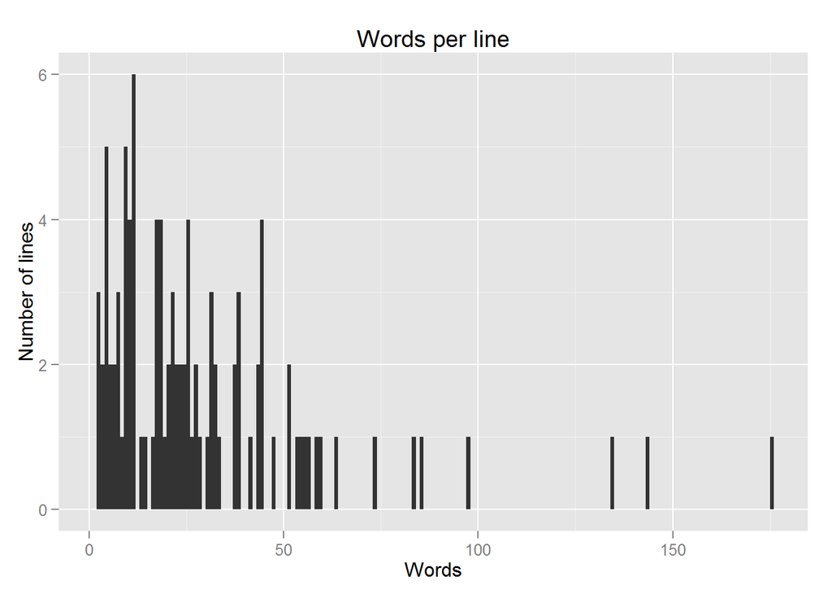

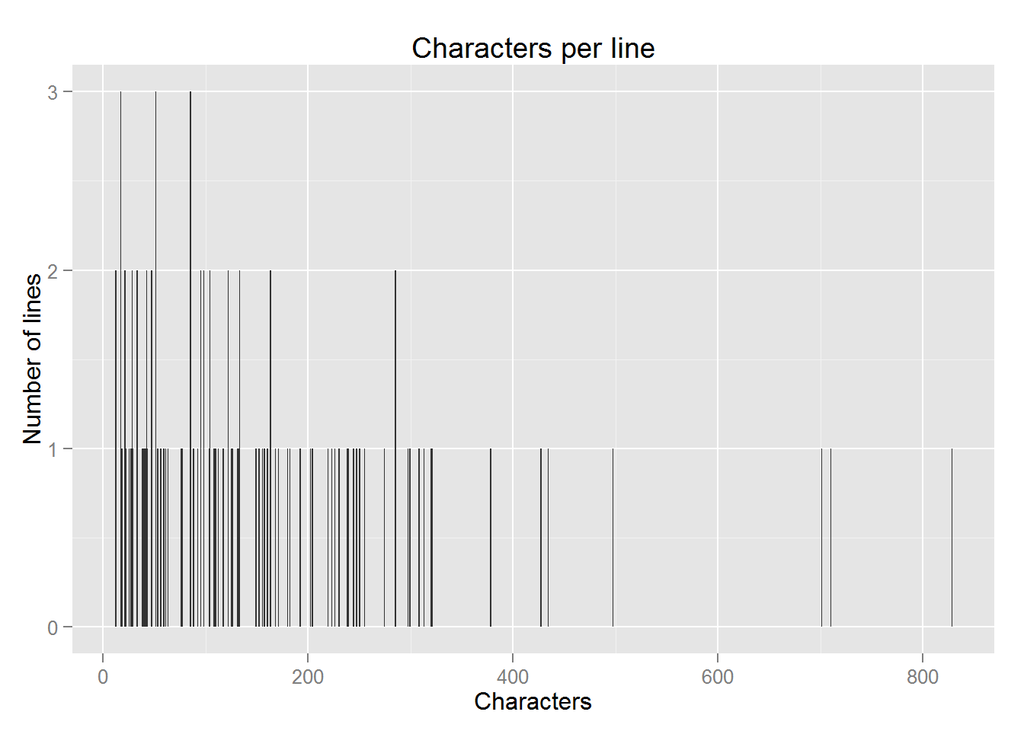

### Which words occur the most?

```
##        word freq
## and     and   71
## ll       ll   70
## i         i   69
## as       as   68
## time   time   67
## going going   67
## its     its   67
## how     how   67
## can     can   67
## other other   67
```

### Which combinations of 2 words occur the most?

```
##          2 word combinations freq
## don t                  don t   10
## of the                of the   10
## it s                    it s    9
## and then            and then    8
## on the                on the    8
## to be                  to be    8
## on your              on your    7
## for the              for the    7
## be a                    be a    6
## if you                if you    6
```

### Which combinations of 3 words occur the most?

```
##                   3 word combinations freq
## call your parents   call your parents    4
## what they are           what they are    4
## to be a                       to be a    4
## you don t                   you don t    3
## to call your             to call your    3
## and then you             and then you    3
## it it was                   it it was    3
## there s no                 there s no    3
## on your own               on your own    3
## a bit of                     a bit of    3
```